# 2026 Bay Area Used Vehicle Market Analysis

Alejandro Alvarez

2026-06-05

# Overview

## 16,000

Raw Listings

## 14,320

Modeling Observations

## 90.3%

Random Forest Variance Explained

This project analyzes approximately 16,000 used vehicle listings collected from Craigslist in the San Francisco Bay Area during 2026. The objective is to understand how factors such as vehicle age, mileage, and model characteristics influence vehicle prices. The project includes data collection, cleaning, exploratory data analysis (EDA), regression modeling, and machine learning techniques to identify key drivers of vehicle value.

# Data Collection

Vehicle listings were collected from Craigslist’s San Francisco Bay Area automobile marketplace using Python and Playwright. Search result pages were downloaded and parsed into a structured dataset containing vehicle title, year, mileage, and asking price information. The final dataset contains approximately 16,000 observations.

# Data Cleaning

After cleaning, the final modeling dataset contains 14,320 listings.

Project Summary

| Metric | Value |
| --- | --- |
| Raw Listings | 16,000 |
| Cleaned Listings | 15,280 |
| Modeling Observations | 14,320 |
| Linear Regression R² | 42.4% |
| Random Forest Variance Explained | 90.3% |

# Exploratory Data Analysis

The exploratory data analysis examined the relationships between vehicle price, mileage, and model year. The dataset contained approximately 14,320 cleaned observations after removing missing values and extreme outliers.

## Price vs Mileage

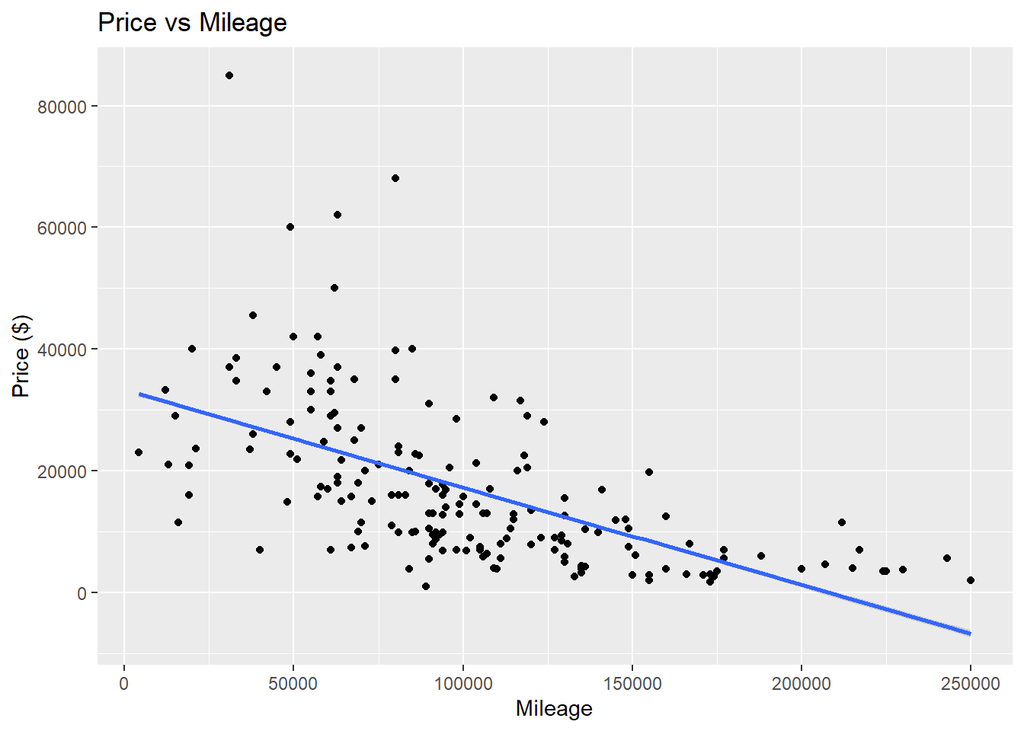

## Vehicle Age Analysis

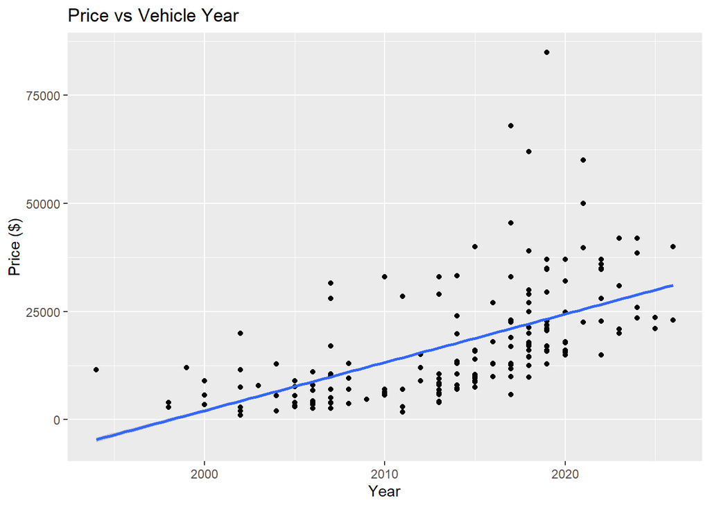

## Linear Regression Model

A multiple linear regression model was estimated using vehicle price as the dependent variable and mileage and model year as explanatory variables. Both variables were statistically significant at the 1% level (p < 0.001). Mileage exhibited a negative relationship with price, while newer model years were associated with higher vehicle values. The model achieved an R-squared of 0.424, indicating that approximately 42.4% of the variation in vehicle prices can be explained by mileage and vehicle year.

## Random Forest Model

A Random Forest regression model was estimated using vehicle mileage and model year as predictors of vehicle price. The model consisted of 500 decision trees and explained approximately 90.3% of the variation in vehicle prices. Compared to the linear regression model (R² = 42.4%), the Random Forest demonstrated substantially improved predictive performance, suggesting that vehicle pricing relationships are nonlinear and better captured through machine learning techniques.

```
##         IncNodePurity
## mileage  1.288360e+12
## year     9.444867e+11
```

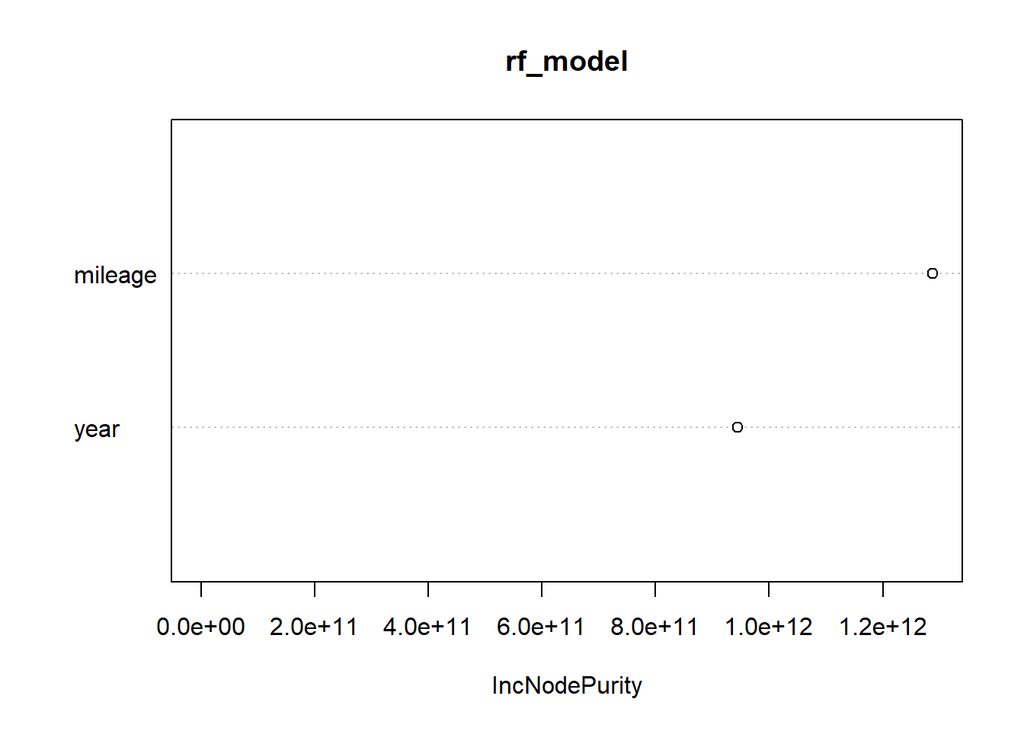

Variable importance analysis revealed that mileage was the most influential predictor of vehicle price, followed by vehicle year. This result is consistent with economic intuition, as vehicle depreciation is strongly associated with accumulated mileage. While newer vehicles generally command higher prices, mileage appears to be the dominant factor in determining market value within the Craigslist dataset.

# Key Findings

- The final dataset contained approximately 14,320 cleaned vehicle listings after removing incomplete observations and outliers.
- Vehicle prices exhibited a negative relationship with mileage and a positive relationship with model year.
- The linear regression model explained approximately 42.4% of the variation in vehicle prices.
- The Random Forest model explained approximately 90.3% of the variation in vehicle prices, substantially outperforming the linear regression model.
- Mileage was identified as the most important predictor of vehicle value, followed by vehicle year.

# Conclusion

This project analyzed thousands of used vehicle listings from the San Francisco Bay Area Craigslist marketplace. The results demonstrate that vehicle mileage and model year are significant determinants of vehicle price. While a traditional linear regression model provided useful insights, machine learning methods substantially improved predictive performance. The Random Forest model explained over 90% of the variation in vehicle prices, highlighting the benefits of nonlinear modeling techniques when analyzing vehicle markets.